# Guía definitiva de estadística descriptiva y visualización biomédica en R

## 2.4 Estructura del dataframe biomédico

```r
head(datos)
```

| id_paciente | grupo | hemoglobina_g_dl | pcr_mg_l |
| --- | --- | --- | --- |
| PX01 | Control | 12.4 | 0.2 |
| PX02 | Enfermedad estable | 11.9 | 0.6 |
| PX03 | Enfermedad activa | 11.5 | 0.8 |
| PX04 | Control | 13.1 | 0.3 |
| PX05 | Enfermedad estable | 12.7 | 0.8 |
| PX06 | Enfermedad activa | 12.2 | 1.0 |

| Variable | Tipo esperado | Significado |
| --- | --- | --- |
| `id_paciente` | Texto | Identificador sintético y anonimizado. |
| `grupo` | Texto o factor | Control, enfermedad estable o enfermedad activa. |
| `hemoglobina_g_dl` | Numérica continua | Concentración de hemoglobina en g/dL. |
| `pcr_mg_l` | Numérica continua positiva | Proteína C reactiva en mg/L. |

Una fila representa un paciente. Una columna representa una variable. Esta estructura es fundamental: si un paciente aparece en varias filas porque se midió en varios tiempos, el diseño deja de ser transversal y el análisis debe reconocer la dependencia entre observaciones.

## 2.5 Inspección inicial

```r
glimpse(datos)
```

```
## Rows: 36
## Columns: 4
## $ id_paciente      <chr> "PX01", "PX02", "PX03", "PX04", "PX05", "PX06", "PX07", "PX08", "PX09", "…
## $ grupo            <chr> "Control", "Enfermedad estable", "Enfermedad activa", "Control", "Enferme…
## $ hemoglobina_g_dl <dbl> 12.4, 11.9, 11.5, 13.1, 12.7, 12.2, NA, 13.0, 12.6, 13.7, 13.2, 12.9, 13.…
## $ pcr_mg_l         <dbl> 0.2, 0.6, 0.8, 0.3, 0.8, 1.0, 0.4, 0.9, 1.2, 0.5, 1.0, NA, 0.6, 1.1, 1.8,…
```

```r
summary(datos)
```

```
##     id_paciente       grupo    hemoglobina_g_dl    pcr_mg_l
##  Length   :36   Length   :36   Min.   :11.50    Min.   : 0.200
##  N.unique :36   N.unique : 3   1st Qu.:13.10    1st Qu.: 0.800
##  N.blank  : 0   N.blank  : 0   Median :13.75    Median : 1.150
##  Min.nchar: 4   Min.nchar: 7   Mean   :13.69    Mean   : 2.385
##  Max.nchar: 4   Max.nchar:18   3rd Qu.:14.35    3rd Qu.: 2.175
##                                Max.   :15.50    Max.   :18.600
##                                NAs    :2        NAs    :2
```

```r
colSums(is.na(datos))
```

```
##      id_paciente            grupo hemoglobina_g_dl         pcr_mg_l
##                0                0                2                2
```

### 2.5.1 `glimpse(datos)`

Muestra el número de filas y columnas, el nombre de cada variable, su tipo y algunos valores. Permite detectar problemas como una concentración almacenada como texto debido a símbolos, comas decimales o códigos especiales.

### 2.5.2 `summary(datos)`

Produce un resumen rápido. Para columnas numéricas muestra mínimo, cuartiles, mediana, media, máximo y cantidad de `NA`. Su función aquí es diagnóstica. Todavía no constituye la tabla final.

### 2.5.3 `is.na(datos)` y `colSums()`

`is.na(datos)` crea una matriz de valores `TRUE` y `FALSE`. `TRUE` indica ausencia. `colSums()` cuenta los `TRUE` por columna porque, en una suma, R trata `TRUE` como 1 y `FALSE` como 0.

### 2.5.4 Cómo modificarlo

Para contar ausencias por fila:

```r
rowSums(is.na(datos))
```

Para observar solo las filas que tienen al menos una ausencia:

```r
datos |>
  filter(if_any(everything(), is.na))
```

## 2.6 Limpieza de valores ausentes

```r
datos_limpios <- datos |>
  drop_na(hemoglobina_g_dl, pcr_mg_l)

nrow(datos)
```

```
## [1] 36
```

```r
nrow(datos_limpios)
```

```
## [1] 32
```

### 2.6.1 Lectura línea por línea

- `datos |>` envía el dataframe a la siguiente función. El operador `|>` puede leerse como “y después”.
- `drop_na(hemoglobina_g_dl, pcr_mg_l)` conserva solo las filas que tienen valores para ambos biomarcadores.
- El resultado se guarda en `datos_limpios`. El objeto `datos` permanece intacto.
- `nrow()` compara el tamaño antes y después. En el ejemplo se pasa de 36 a 32 pacientes.

### 2.6.2 Propósito estadístico

Las funciones `mean()`, `sd()` y `shapiro.test()` no deben recibir ausencias sin que se les indique cómo manejarlas. El ejemplo utiliza eliminación por casos completos para mantener sencillo el flujo docente.

### 2.6.3 Advertencia biomédica

Eliminar casos no siempre es una decisión neutral. Si las ausencias se relacionan con la gravedad, el tratamiento, el pronóstico o cualquier característica clínica, el subconjunto completo puede quedar sesgado. En un análisis real deben describirse el patrón y la causa probable de los datos faltantes. Según el diseño, podrían requerirse análisis de sensibilidad o imputación.

### 2.6.4 Cómo modificarlo

Para analizar la hemoglobina sin exigir que PCR esté disponible:

```r
datos_hemoglobina <- datos |>
  drop_na(hemoglobina_g_dl)
```

Para conservar las filas y permitir que cada estadístico ignore sus propios `NA`:

```r
mean(datos$hemoglobina_g_dl, na.rm = TRUE)
```

Ambas estrategias producen tamaños muestrales distintos. El valor de `n` debe reportarse para cada variable.

## 2.7 Transformación a formato largo

```r
datos_largos <- datos_limpios |>
  pivot_longer(
    cols = c(hemoglobina_g_dl, pcr_mg_l),
    names_to = "variable",
    values_to = "valor"
  )

head(datos_largos)
```

| id_paciente | grupo | variable | valor |
| --- | --- | --- | --- |
| PX01 | Control | hemoglobina_g_dl | 12.4 |
| PX01 | Control | pcr_mg_l | 0.2 |
| PX02 | Enfermedad estable | hemoglobina_g_dl | 11.9 |
| PX02 | Enfermedad estable | pcr_mg_l | 0.6 |
| PX03 | Enfermedad activa | hemoglobina_g_dl | 11.5 |
| PX03 | Enfermedad activa | pcr_mg_l | 0.8 |

### 2.7.1 Por qué se realiza

Antes de la transformación hay dos columnas de biomarcadores. Después, sus nombres quedan en `variable` y sus mediciones en `valor`. Este formato permite agrupar por variable y repetir la misma prueba o el mismo gráfico sin copiar el código.

### 2.7.2 Significado de los argumentos

- `cols = c(...)` selecciona las columnas que se apilarán.
- `names_to = "variable"` define dónde se guardarán los nombres originales.
- `values_to = "valor"` define dónde se guardarán las mediciones.

### 2.7.3 Cómo modificarlo

Para añadir glucosa:

```r
datos_largos <- datos_limpios |>
  pivot_longer(
    cols = c(hemoglobina_g_dl, pcr_mg_l, glucosa_mg_dl),
    names_to = "variable",
    values_to = "valor"
  )
```

Todas las columnas apiladas deben tener tipos compatibles. No mezcle texto clínico con concentraciones numéricas dentro de `valor`.

## 2.8 Inspección gráfica de la distribución

### 2.8.1 Histogramas

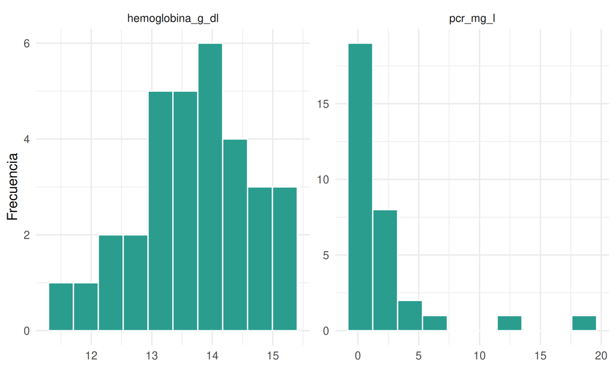

Histogramas de los dos biomarcadores después de eliminar casos incompletos.

```r
grafico_histograma <- ggplot(datos_largos, aes(x = valor)) +
  geom_histogram(bins = 10, fill = "#2A9D8F", color = "white") +
  facet_wrap(~ variable, scales = "free") +
  labs(x = NULL, y = "Frecuencia") +
  theme_minimal(base_size = 13)

grafico_histograma
```

#### 2.8.1.1 Qué aporta cada parte

- `ggplot(datos_largos, aes(x = valor))` define los datos y coloca las mediciones en el eje horizontal.
- `geom_histogram()` divide el intervalo de valores en clases y cuenta cuántas observaciones caen en cada una.
- `bins = 10` solicita diez intervalos. Cambiarlo puede alterar la apariencia, por lo que conviene probar varias opciones.
- `facet_wrap(~ variable)` crea un panel para cada biomarcador.
- `scales = "free"` permite que cada panel tenga su propia escala. Esto es necesario porque hemoglobina y PCR tienen unidades y rangos diferentes.

#### 2.8.1.2 Qué buscar

Se evalúan simetría, concentración central, colas, huecos y observaciones alejadas. La hemoglobina se aproxima a una forma simétrica. La PCR presenta una cola derecha larga, frecuente en biomarcadores inflamatorios.

#### 2.8.1.3 Cómo modificarlo

Para fijar el ancho de cada intervalo en lugar de su número:

```r
geom_histogram(binwidth = 0.5)
```

El ancho debe expresarse en las mismas unidades de la variable.

### 2.8.2 Gráficos Q-Q

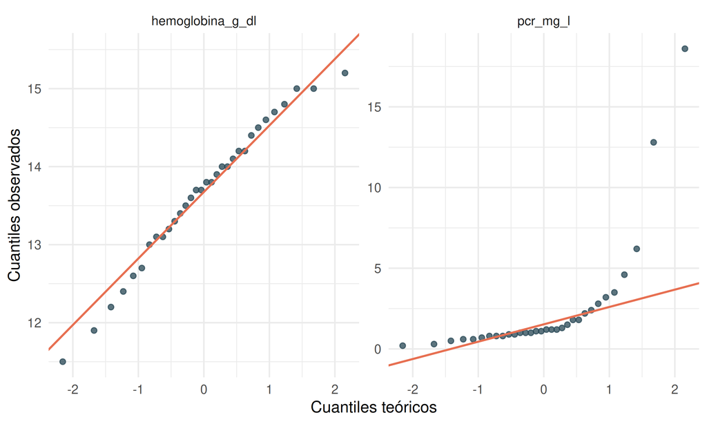

Gráficos Q-Q utilizados como apoyo visual para evaluar normalidad.

```r
grafico_qq <- ggplot(datos_largos, aes(sample = valor)) +
  stat_qq(color = "#264653", alpha = 0.75) +
  stat_qq_line(color = "#E76F51", linewidth = 0.8) +
  facet_wrap(~ variable, scales = "free") +
  labs(x = "Cuantiles teóricos", y = "Cuantiles observados") +
  theme_minimal(base_size = 13)

grafico_qq
```

Un gráfico Q-Q compara los cuantiles observados con los cuantiles que se esperarían bajo una distribución normal. Una alineación aproximada apoya la compatibilidad con normalidad. Curvaturas sistemáticas o desviaciones grandes en los extremos indican asimetría o colas diferentes.

- `aes(sample = valor)` declara la variable cuya distribución se comparará.
- `stat_qq()` dibuja los puntos.
- `stat_qq_line()` añade una referencia.
- `alpha = 0.75` hace los puntos parcialmente transparentes.

El gráfico Q-Q no produce una decisión automática. Su lectura se combina con el histograma, la naturaleza de la variable y la prueba formal.

## 2.9 Prueba de Shapiro-Wilk

```r
normalidad <- datos_largos |>
  group_by(variable) |>
  summarise(
    n_total = n(),
    W = unname(shapiro.test(valor)$statistic),
    p = shapiro.test(valor)$p.value,
    .groups = "drop"
  ) |>
  mutate(
    decision = if_else(
      p >= 0.05,
      "Compatible con normalidad",
      "No compatible con normalidad"
    ),
    resumen_a_reportar = if_else(
      p >= 0.05,
      "Media ± DE",
      "Mediana (Q1-Q3)"
    )
  )

normalidad |>
  mutate(across(c(W, p), ~ signif(.x, 4))) |>
  kable()
```

| variable | n_total | W | p | decision | resumen_a_reportar |
| --- | --- | --- | --- | --- | --- |
| hemoglobina_g_dl | 32 | 0.9771 | 0.7129 | Compatible con normalidad | Media ± DE |
| pcr_mg_l | 32 | 0.5307 | 0.0000 | No compatible con normalidad | Mediana (Q1-Q3) |

### 2.9.1 Hipótesis e interpretación

La hipótesis nula de Shapiro-Wilk establece que los datos son compatibles con una distribución normal (referencias 2 y 3).

- Si `p < 0.05`, el ejercicio rechaza la hipótesis nula y clasifica la variable como no normal.
- Si `p >= 0.05`, el ejercicio no encuentra evidencia suficiente para rechazarla.

“No rechazar” no demuestra normalidad. Con pocas observaciones, la prueba puede carecer de potencia. Con muestras muy grandes, puede detectar desviaciones pequeñas sin relevancia práctica. Por eso la prueba debe acompañarse de gráficos (referencia 3).

### 2.9.2 Lectura del código

- `group_by(variable)` separa internamente hemoglobina y PCR.
- `summarise()` devuelve una fila por variable.
- `n()` cuenta observaciones.
- `shapiro.test(valor)$statistic` extrae W.
- `shapiro.test(valor)$p.value` extrae el valor p.
- `unname()` elimina el nombre interno del estadístico para facilitar su almacenamiento.
- `.groups = "drop"` devuelve un dataframe sin agrupación activa.
- `if_else()` traduce una condición lógica a una frase pedagógica.

### 2.9.3 Resultado del ejemplo

- Hemoglobina: `W ≈ 0.977`, `p ≈ 0.713`.
- PCR: `W ≈ 0.531`, `p < 0.001`.

### 2.9.4 Cómo modificarlo

Para evaluar normalidad dentro de cada grupo:

```r
datos_largos |>
  group_by(variable, grupo) |>
  summarise(
    n = n(),
    W = unname(shapiro.test(valor)$statistic),
    p = shapiro.test(valor)$p.value,
    .groups = "drop"
  )
```

Esta modificación puede ser más coherente cuando se comparan grupos, pero los tamaños pequeños vuelven inestable la prueba. En modelos inferenciales suele ser más apropiado evaluar los residuos que aplicar Shapiro-Wilk directamente a cada variable.

## 2.10 Estadística descriptiva paramétrica y no paramétrica

```r
descriptivos <- datos_largos |>
  group_by(variable, grupo) |>
  summarise(
    n = n(),
    media = mean(valor),
    DE = sd(valor),
    mediana = median(valor),
    Q1 = quantile(valor, 0.25),
    Q3 = quantile(valor, 0.75),
    minimo = min(valor),
    maximo = max(valor),
    .groups = "drop"
  )

descriptivos |>
  mutate(across(where(is.numeric), ~ round(.x, 2))) |>
  kable()
```

| variable | grupo | n | media | DE | mediana | Q1 | Q3 | minimo | maximo |
| --- | --- | --- | --- | --- | --- | --- | --- | --- | --- |
| hemoglobina_g_dl | Control | 10 | 14.00 | 0.80 | 14.10 | 13.72 | 14.55 | 12.4 | 15.0 |
| hemoglobina_g_dl | Enfermedad activa | 11 | 13.40 | 1.02 | 13.50 | 12.85 | 14.00 | 11.5 | 15.0 |
| hemoglobina_g_dl | Enfermedad estable | 11 | 13.61 | 0.93 | 13.60 | 13.10 | 14.10 | 11.9 | 15.2 |
| pcr_mg_l | Control | 10 | 0.73 | 0.33 | 0.75 | 0.52 | 0.98 | 0.2 | 1.2 |
| pcr_mg_l | Enfermedad activa | 11 | 5.05 | 5.66 | 2.80 | 1.50 | 5.40 | 0.8 | 18.6 |
| pcr_mg_l | Enfermedad estable | 11 | 1.44 | 0.77 | 1.20 | 0.95 | 1.65 | 0.6 | 3.2 |

### 2.10.1 Qué representa cada estadístico

- `n`: cantidad de pacientes incluidos.
- `media`: suma de los valores dividida entre `n`. Es sensible a observaciones extremas.
- `DE`: desviación estándar. Resume la dispersión alrededor de la media.
- `mediana`: valor central después de ordenar las observaciones. Es más resistente a extremos.
- `Q1`: percentil 25.
- `Q3`: percentil 75.
- `Q3 - Q1`: rango intercuartílico o RIQ.
- `minimo` y `maximo`: extremos observados, útiles para control de calidad.

La práctica calcula ambas familias para que puedan compararse. El reporte principal utiliza media ± DE para la hemoglobina y mediana (Q1-Q3) para PCR.

### 2.10.2 Cómo modificarlo

Para añadir coeficiente de variación, apropiado solo cuando tiene sentido dividir la DE entre una media positiva:

```r
CV_porcentaje = 100 * DE / media
```

Para cambiar el algoritmo de cuartiles debe utilizarse el argumento `type` de `quantile()`. R ofrece varios métodos, y programas distintos pueden producir pequeñas diferencias en muestras pequeñas.

## 2.11 Unión entre prueba y descriptivos

```r
tabla_reporte <- descriptivos |>
  left_join(normalidad, by = "variable") |>
  mutate(
    medida = recode(
      variable,
      hemoglobina_g_dl = "Hemoglobina (g/dL)",
      pcr_mg_l = "Proteína C reactiva (mg/L)"
    ),
    resultado = if_else(
      p >= 0.05,
      sprintf("%.2f ± %.2f", media, DE),
      sprintf("%.1f (%.1f-%.1f)", mediana, Q1, Q3)
    ),
    p_shapiro = if_else(
      p < 0.001,
      "<0.001",
      sprintf("%.3f", p)
    )
  ) |>
  select(medida, grupo, n, resultado, p_shapiro, resumen_a_reportar)

tabla_reporte |>
  kable()
```

| medida | grupo | n | resultado | p_shapiro | resumen_a_reportar |
| --- | --- | --- | --- | --- | --- |
| Hemoglobina (g/dL) | Control | 10 | 14.00 ± 0.80 | 0.713 | Media ± DE |
| Hemoglobina (g/dL) | Enfermedad activa | 11 | 13.40 ± 1.02 | 0.713 | Media ± DE |
| Hemoglobina (g/dL) | Enfermedad estable | 11 | 13.61 ± 0.93 | 0.713 | Media ± DE |
| Proteína C reactiva (mg/L) | Control | 10 | 0.8 (0.5-1.0) | <0.001 | Mediana (Q1-Q3) |
| Proteína C reactiva (mg/L) | Enfermedad activa | 11 | 2.8 (1.5-5.4) | <0.001 | Mediana (Q1-Q3) |
| Proteína C reactiva (mg/L) | Enfermedad estable | 11 | 1.2 (0.9-1.6) | <0.001 | Mediana (Q1-Q3) |

### 2.11.1 Por qué se usa `left_join()`

`descriptivos` tiene una fila por combinación de variable y grupo. `normalidad` tiene una fila por variable. `left_join(..., by = "variable")` copia la decisión correspondiente a todas las filas de esa variable.

### 2.11.2 Formato con `sprintf()`

- `%.2f` imprime dos decimales.
- `%.1f` imprime un decimal.
- El texto alrededor de los marcadores se conserva.

Los decimales deben decidirse según la precisión del instrumento y la convención clínica. No se deben añadir cifras que el método de medición no puede justificar.

### 2.11.3 Cómo modificarlo

Para reportar un decimal en media y DE:

```r
sprintf("%.1f ± %.1f", media, DE)
```

Para usar otro umbral pedagógico, cambie `0.05` en ambos `if_else()`. En investigación, el umbral debe definirse antes de observar los resultados y no reemplaza el razonamiento sobre supuestos.

# 3 Presentación principal, sesión 2: reporte de resultados

## 3.1 Tabla académica con `gt`

```r
tabla_academica <- tabla_reporte |>
  gt(groupname_col = "medida") |>
  cols_label(
    grupo = "Grupo clínico",
    n = "n",
    resultado = "Resumen",
    p_shapiro = "p de Shapiro-Wilk",
    resumen_a_reportar = "Medida reportada"
  ) |>
  tab_header(
    title = md("**Tabla 1. Estadística descriptiva de los biomarcadores**")
  ) |>
  tab_source_note(
    md("DE: desviación estándar; Q1-Q3: rango intercuartílico.")
  ) |>
  opt_row_striping() |>
  tab_options(
    table.font.names = "Arial",
    table.font.size = px(13),
    heading.align = "left",
    data_row.padding = px(5)
  )

if (identical(knitr::opts_knit$get("rmarkdown.pandoc.to"), "html")) {
  tabla_academica
} else {
  tabla_reporte |>
    kable(caption = "Tabla 1. Estadística descriptiva de los biomarcadores")
}
```

**Tabla 1. Estadística descriptiva de los biomarcadores**

| Grupo clínico | n | Resumen | p de Shapiro-Wilk | Medida reportada |
| --- | --- | --- | --- | --- |
| Hemoglobina (g/dL) |  |  |  |  |
| Control | 10 | 14.00 ± 0.80 | 0.713 | Media ± DE |
| Enfermedad activa | 11 | 13.40 ± 1.02 | 0.713 | Media ± DE |
| Enfermedad estable | 11 | 13.61 ± 0.93 | 0.713 | Media ± DE |
| Proteína C reactiva (mg/L) |  |  |  |  |
| Control | 10 | 0.8 (0.5-1.0) | <0.001 | Mediana (Q1-Q3) |
| Enfermedad activa | 11 | 2.8 (1.5-5.4) | <0.001 | Mediana (Q1-Q3) |
| Enfermedad estable | 11 | 1.2 (0.9-1.6) | <0.001 | Mediana (Q1-Q3) |

DE: desviación estándar; Q1-Q3: rango intercuartílico.

### 3.1.1 Explicación de las capas de la tabla

- `gt()` convierte un dataframe en una tabla presentable.
- `groupname_col = "medida"` utiliza el biomarcador como encabezado de grupo.
- `cols_label()` cambia nombres técnicos sin renombrar el dataframe original.
- `tab_header()` añade número y título.
- `tab_source_note()` explica abreviaturas y decisiones necesarias.
- `opt_row_striping()` alterna un sombreado ligero. Puede eliminarse si la revista exige fondo blanco.
- `tab_options()` controla tipografía, alineación y espaciado.

### 3.1.2 Vancouver y tablas

Vancouver regula principalmente la citación y la lista de referencias. No define una única apariencia universal de tabla. Una tabla biomédica suele incluir número, título breve, unidades, `n`, abreviaturas explicadas y pocas líneas. Siempre prevalecen las instrucciones de la revista.

### 3.1.3 Exportación

```r
gtsave(tabla_academica, "resultados/tabla_1_descriptivos.html")
write_csv(tabla_reporte, "resultados/tabla_1_descriptivos.csv")
```

El HTML conserva el formato visual. El CSV conserva el contenido en una forma fácil de revisar. Una tabla de publicación debe verificarse después de insertarla en el manuscrito.

## 3.2 Figura paramétrica: hemoglobina

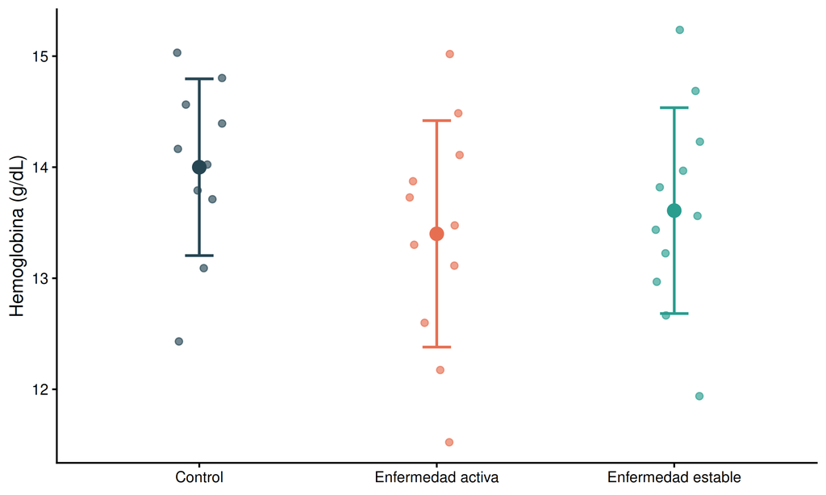

Hemoglobina por grupo clínico. Los puntos muestran pacientes individuales; el punto grande y las barras representan media y una desviación estándar.

```r
grafico_hemoglobina <- ggplot(
  datos_limpios,
  aes(x = grupo, y = hemoglobina_g_dl, color = grupo)
) +
  geom_jitter(width = 0.12, alpha = 0.65, size = 2) +
  stat_summary(fun = mean, geom = "point", size = 4) +
  stat_summary(
    fun.data = mean_sdl,
    fun.args = list(mult = 1),
    geom = "errorbar",
    width = 0.12,
    linewidth = 0.9
  ) +
  scale_color_manual(values = c(
    "Control" = "#264653",
    "Enfermedad estable" = "#2A9D8F",
    "Enfermedad activa" = "#E76F51"
  )) +
  labs(x = NULL, y = "Hemoglobina (g/dL)") +
  theme_classic(base_size = 13) +
  theme(legend.position = "none")

grafico_hemoglobina
```

### 3.2.1 Explicación

- `aes(color = grupo)` vincula el color a una variable. Por ello cada grupo recibe un color consistente.
- `geom_jitter()` desplaza ligeramente los puntos en horizontal para evitar superposición. No modifica su valor vertical.
- El primer `stat_summary()` calcula y dibuja la media.
- El segundo calcula media ± una DE porque `mult = 1`.
- `scale_color_manual()` fija los colores. Sin esta línea, ggplot2 elige una paleta automáticamente.
- `theme_classic()` elimina el fondo gris y conserva los ejes.
- La leyenda se elimina porque los nombres ya aparecen en el eje horizontal.

### 3.2.2 Modificaciones útiles

Para mostrar error estándar en lugar de DE tendría que definirse explícitamente. No cambie la medida sin actualizar el pie de figura. La DE describe variabilidad entre pacientes; el error estándar describe la precisión de la media. No son intercambiables.

## 3.3 Figura no paramétrica: proteína C reactiva

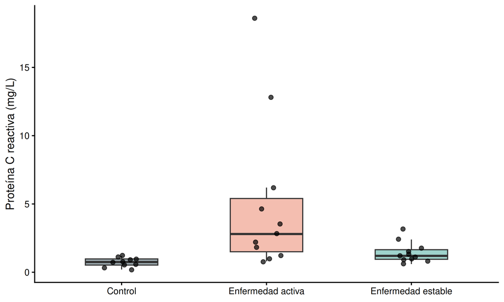

Proteína C reactiva por grupo clínico. Las cajas muestran mediana y rango intercuartílico; los puntos representan pacientes individuales.

```r
grafico_pcr <- ggplot(
  datos_limpios,
  aes(x = grupo, y = pcr_mg_l, fill = grupo)
) +
  geom_boxplot(width = 0.5, alpha = 0.45, outlier.shape = NA) +
  geom_jitter(width = 0.12, alpha = 0.70, size = 2) +
  scale_fill_manual(values = c(
    "Control" = "#264653",
    "Enfermedad estable" = "#2A9D8F",
    "Enfermedad activa" = "#E76F51"
  )) +
  labs(x = NULL, y = "Proteína C reactiva (mg/L)") +
  theme_classic(base_size = 13) +
  theme(legend.position = "none")

grafico_pcr
```

### 3.3.1 Por qué se combinan cajas y puntos

Un boxplot resume mediana, cuartiles y extensión de los datos, pero puede ocultar el tamaño muestral y la forma exacta de una muestra pequeña. Mostrar los puntos individuales permite evaluar agrupaciones, huecos y observaciones extremas. Esta práctica responde a recomendaciones para mejorar la transparencia de figuras biomédicas (referencia 4).

`outlier.shape = NA` evita que `geom_boxplot()` dibuje por segunda vez los puntos situados fuera de los bigotes. No elimina observaciones: `geom_jitter()` sigue mostrando todas.

### 3.3.2 Escala logarítmica

PCR suele ser asimétrica. Si la pregunta y la revista lo justifican, puede considerarse una escala logarítmica:

```r
grafico_pcr +
  scale_y_log10()
```

La escala debe declararse en el eje o en el pie. No puede aplicarse directamente si existen ceros o valores negativos. Una transformación visual tampoco convierte automáticamente el análisis estadístico en apropiado.

## 3.4 Redacción de resultados

Un reporte descriptivo debe indicar variable, criterio de distribución, medida elegida y unidades. Ejemplos:

> La hemoglobina fue compatible con una distribución normal (Shapiro-Wilk, W = 0.977, p = 0.713), por lo que se resumió como media ± DE.

> La proteína C reactiva mostró una distribución asimétrica (Shapiro-Wilk, W = 0.531, p < 0.001), por lo que se resumió como mediana (Q1-Q3).

Estas frases no prueban diferencias entre grupos. Para afirmar una diferencia se necesita una prueba inferencial coherente con la pregunta, el diseño, la independencia de las observaciones y los supuestos.

# 4 Infografía complementaria: funcionamiento de ggplot2 por capas

## 4.1 La gramática general

ggplot2 utiliza una gramática declarativa: se especifican datos, mapeos y capas, y el sistema construye la figura (referencias 5 y 6). La estructura general es:

```r
ggplot(datos, aes(x, y)) +
  geom_*() +
  scale_*() +
  labs() +
  theme_*()
```

| Componente | Responsabilidad | Ejemplo |
| --- | --- | --- |
| Datos | Proporcionan las filas que se representarán. | `datos_limpios` |
| Mapeo estético | Relaciona variables con ejes, color, forma o tamaño. | `aes(x = grupo, y = pcr_mg_l)` |
| Geometría | Decide cómo se dibujan las observaciones o resúmenes. | `geom_boxplot()` |
| Estadística | Calcula resúmenes cuando la geometría lo requiere. | Cuartiles del boxplot |
| Escala | Traduce datos a posiciones, colores o etiquetas. | `scale_fill_manual()` |
| Coordenadas | Define la región y el sistema de representación. | `coord_cartesian()` |
| Facetas | Divide una figura en paneles. | `facet_wrap()` |
| Tema | Controla elementos no asociados a datos. | `theme_classic()` |

El signo `+` añade una capa al objeto gráfico. No añade columnas al dataframe.

## 4.2 Preparación y orden clínico

```r
datos_caja <- datos_limpios |>
  mutate(
    grupo = factor(
      grupo,
      levels = c("Control", "Enfermedad estable", "Enfermedad activa")
    )
  )
```

`factor()` transforma el grupo en una categoría con orden explícito. Sin `levels`, ggplot2 suele ordenar alfabéticamente. El orden control, enfermedad estable y enfermedad activa comunica mejor la progresión clínica.

Para invertirlo, basta con invertir `levels`. Para añadir otro grupo, agregue su nombre exactamente como aparece en el CSV.

## 4.3 Paso 1: base y gráfica de cajas

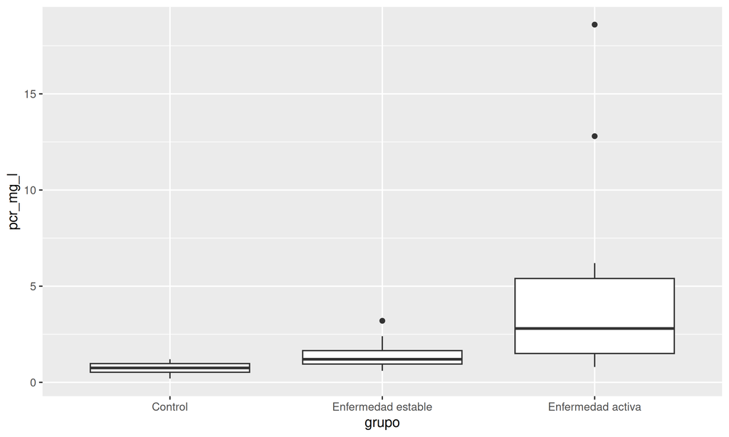

Paso 1. Gráfica de cajas con los valores predeterminados de ggplot2.

```r
paso_1 <- ggplot(
  datos_caja,
  aes(x = grupo, y = pcr_mg_l)
) +
  geom_boxplot()

paso_1
```

`ggplot()` crea la especificación. `aes()` define que cada grupo ocupa una posición horizontal y que PCR determina la posición vertical. `geom_boxplot()` añade una capa que calcula:

- mediana;
- primer y tercer cuartil;
- rango intercuartílico;
- bigotes hasta las observaciones compatibles con 1.5 veces el RIQ;
- puntos fuera de los bigotes.

Un punto fuera de los bigotes no es sinónimo de error. Puede ser una observación biológica válida que requiere comprobación.

## 4.4 Paso 2: pacientes individuales

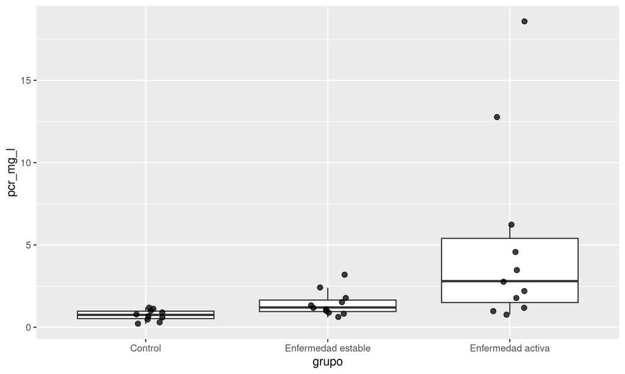

Paso 2. La segunda capa muestra todos los pacientes y evita duplicar los puntos fuera de los bigotes.

```r
paso_2 <- ggplot(
  datos_caja,
  aes(x = grupo, y = pcr_mg_l)
) +
  geom_boxplot(outlier.shape = NA) +
  geom_point(
    position = position_jitter(width = 0.10, seed = 123),
    alpha = 0.75,
    size = 2
  )

paso_2
```

### 4.4.1 Propósito de cada argumento

- `outlier.shape = NA` oculta únicamente la representación automática de extremos del boxplot.
- `geom_point()` dibuja una marca por fila.
- `position_jitter(width = 0.10)` introduce una pequeña separación horizontal.
- `seed = 123` conserva la misma separación al regenerar la figura.
- `alpha = 0.75` controla transparencia.
- `size = 2` controla el tamaño en unidades gráficas, no en unidades clínicas.

Para muestras grandes, reduzca `size` y `alpha`. Para datos pareados, no utilice puntos dispersos como si fueran independientes: considere líneas que conecten mediciones del mismo paciente.

## 4.5 Paso 3: colores y consistencia visual

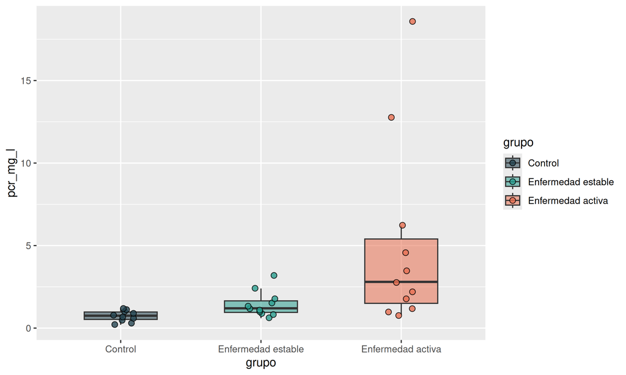

Paso 3. Los colores se asignan a los grupos mediante una escala manual.

```r
colores_grupo <- c(
  "Control" = "#264653",
  "Enfermedad estable" = "#2A9D8F",
  "Enfermedad activa" = "#E76F51"
)

paso_3 <- ggplot(
  datos_caja,
  aes(x = grupo, y = pcr_mg_l, fill = grupo)
) +
  geom_boxplot(width = 0.52, alpha = 0.55, outlier.shape = NA) +
  geom_point(
    position = position_jitter(width = 0.10, seed = 123),
    shape = 21,
    size = 2.2,
    alpha = 0.80
  ) +
  scale_fill_manual(values = colores_grupo)

paso_3
```

`fill = grupo` se encuentra dentro de `aes()` porque el relleno depende de una variable. `scale_fill_manual()` traduce cada categoría a un código hexadecimal. `shape = 21` permite que los puntos tengan relleno y borde.

Si se escribe `fill = "#2A9D8F"` fuera de `aes()`, todas las cajas reciben un color fijo. Dentro de `aes()`, una cadena se interpreta como una categoría y puede crear una leyenda accidental.

## 4.6 Paso 4: unidades, tamaño muestral y tema

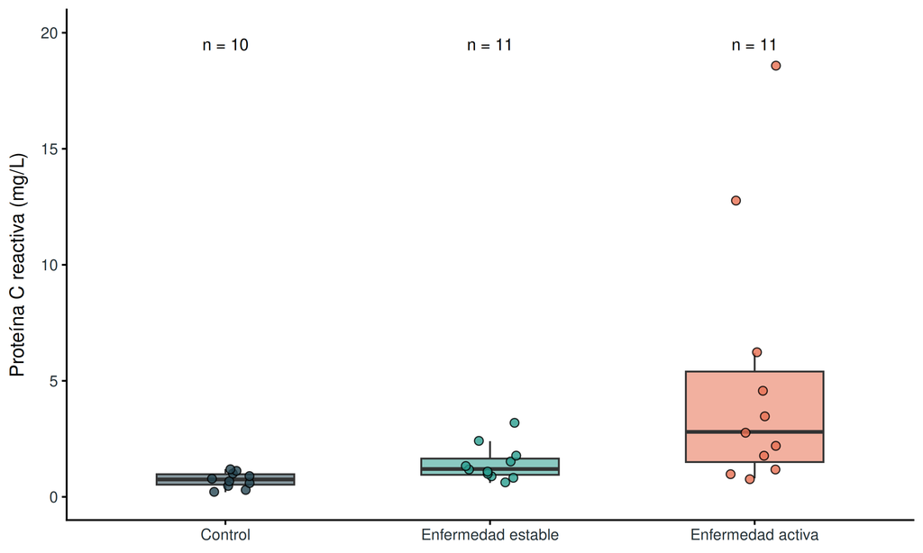

Figura final. Gráfica de cajas apta para integrarse en un manuscrito después de ajustarla a las instrucciones de la revista.

```r
n_grupos <- datos_caja |>
  count(grupo) |>
  mutate(etiqueta = paste0("n = ", n))

grafico_publicacion <- paso_3 +
  geom_text(
    data = n_grupos,
    aes(x = grupo, y = 19.5, label = etiqueta),
    inherit.aes = FALSE,
    size = 3.6
  ) +
  labs(
    x = NULL,
    y = "Proteína C reactiva (mg/L)"
  ) +
  coord_cartesian(ylim = c(0, 20)) +
  theme_classic(base_size = 12) +
  theme(
    legend.position = "none",
    axis.text.x = element_text(color = "#263238"),
    axis.text.y = element_text(color = "#263238"),
    axis.title.y = element_text(margin = margin(r = 8))
  )

grafico_publicacion
```

### 4.6.1 Cálculo del tamaño muestral

`count(grupo)` cuenta filas por categoría. `paste0("n = ", n)` construye las etiquetas. Esta tabla pequeña se proporciona solo a `geom_text()`.

### 4.6.2 `inherit.aes = FALSE`

La gráfica principal espera `y = pcr_mg_l`, pero `n_grupos` no tiene esa columna. `inherit.aes = FALSE` impide que la capa de texto herede ese mapeo y permite definir uno nuevo.

### 4.6.3 Etiquetas y coordenadas

- `x = NULL` elimina un título redundante del eje horizontal.
- El eje vertical incluye el nombre completo y la unidad.
- `coord_cartesian(ylim = c(0, 20))` define la ventana visible sin descartar datos antes del cálculo del boxplot.

No debe confundirse con `ylim()`, que puede eliminar observaciones fuera del intervalo y cambiar el resumen calculado.

### 4.6.4 Tema

`theme_classic(base_size = 12)` establece una base limpia. `theme()` modifica elementos concretos. La tipografía debe juzgarse al tamaño físico final, no solo con la gráfica ampliada en pantalla.

## 4.7 Exportación para publicación

```r
ggsave(
  "resultados/infografia_ggplot/pcr_cajas_publicacion.png",
  grafico_publicacion,
  width = 170,
  height = 120,
  units = "mm",
  dpi = 600,
  bg = "white"
)
```

- El primer argumento define el archivo.
- El segundo identifica qué objeto gráfico se exporta.
- `width` y `height` definen el tamaño físico.
- `units = "mm"` evita ambigüedad.
- `dpi = 600` controla la densidad de píxeles del PNG.
- `bg = "white"` evita transparencias inesperadas.

Para una versión vectorial:

```r
ggsave(
  "resultados/infografia_ggplot/pcr_cajas_publicacion.pdf",
  grafico_publicacion,
  width = 170,
  height = 120,
  units = "mm",
  bg = "white"
)
```

El PDF conserva texto y líneas como elementos vectoriales. Algunas revistas solicitan TIFF, EPS o dimensiones exactas. Siempre debe consultarse la guía editorial antes de la exportación final.

# 5 Recetas para adaptar el flujo

## 5.1 Sustituir los biomarcadores

Suponga un nuevo archivo con `glucosa_mg_dl` y `insulina_uUI_ml`.

1. Cambie los nombres dentro de `drop_na()`.
2. Cámbielos dentro de `pivot_longer()`.
3. Actualice `recode()` para crear nombres legibles.
4. Cambie las variables `y` de las figuras.
5. Revise unidades, decimales y límites del eje.

No use búsqueda y reemplazo sin revisar el significado clínico. Una variable binaria, ordinal o de conteo requiere otra descripción.

## 5.2 Dos grupos en lugar de tres

```r
datos_dos_grupos <- datos |>
  filter(grupo %in% c("Control", "Enfermedad activa")) |>
  mutate(grupo = droplevels(factor(grupo)))
```

Después puede reutilizarse el mismo código. Actualice la paleta para que contenga exactamente esos grupos.

## 5.3 Varias visitas por paciente

Si cada paciente tiene basal y seguimiento, debe existir una columna `visita`. Los datos ya no son independientes. Una visualización inicial puede conectar mediciones:

```r
ggplot(datos_pareados, aes(x = visita, y = biomarcador,
                           group = id_paciente)) +
  geom_line(alpha = 0.35) +
  geom_point()
```

El análisis inferencial correspondiente también debe reconocer el emparejamiento.

## 5.4 Paneles para varios biomarcadores

```r
ggplot(datos_largos, aes(x = grupo, y = valor, fill = grupo)) +
  geom_boxplot() +
  facet_wrap(~ variable, scales = "free_y")
```

`free_y` facilita ver variables con escalas distintas, pero impide comparar alturas absolutas entre paneles. Cada panel debe conservar unidades claras.

## 5.5 Cambiar colores

```r
colores_grupo <- c(
  "Control" = "#0072B2",
  "Enfermedad estable" = "#009E73",
  "Enfermedad activa" = "#D55E00"
)
```

Una paleta debe mantener contraste también en impresión y para lectores con deficiencias en la visión del color. El color no debería ser la única señal cuando las categorías pueden identificarse mediante posición, forma o etiquetas.

# 6 Errores frecuentes y solución

| Problema | Causa probable | Solución |
| --- | --- | --- |
| “No se encuentra el archivo” | El proyecto se abrió desde otra carpeta. | Abra el `.Rproj` y confirme la ruta relativa. |
| “No se encuentra la función” | Falta cargar el paquete. | Ejecute el `library()` correspondiente. |
| Una columna numérica aparece como texto | Símbolos, comas decimales o códigos no numéricos. | Inspeccione valores únicos y defina reglas de importación. |
| `shapiro.test()` falla | Hay `NA`, valores idénticos o un tamaño no admitido. | Limpie ausencias y compruebe variabilidad y tamaño. |
| Los grupos aparecen en orden alfabético | La variable sigue siendo texto. | Conviértala en factor con `levels`. |
| Los puntos extremos aparecen dos veces | Boxplot y puntos los dibujan simultáneamente. | Use `outlier.shape = NA` y conserve `geom_point()`. |
| Aparece una leyenda inesperada | Un valor constante se colocó dentro de `aes()`. | Coloque propiedades constantes fuera de `aes()`. |
| La gráfica cambia cada vez | `jitter` utiliza posiciones aleatorias. | Defina `seed` en `position_jitter()`. |
| La figura se ve bien en pantalla pero mal en el manuscrito | Tamaño físico o tipografía inadecuados. | Exporte con dimensiones finales y revise al 100 %. |

# 7 Lista de comprobación final

Antes de dar por terminado el análisis:

- El archivo original permanece sin cambios.
- Las variables y unidades se verificaron.
- Se documentaron los valores ausentes.
- El tamaño muestral coincide con la limpieza realizada.
- La distribución se examinó gráficamente.
- La prueba de normalidad se interpretó con cautela.
- El resumen corresponde a la distribución y al propósito clínico.
- La tabla explica abreviaturas y unidades.
- La figura muestra datos individuales cuando el tamaño lo permite.
- El pie identifica la medida central y la dispersión.
- La exportación cumple las instrucciones de la revista.
- Los resultados descriptivos no se presentan como evidencia inferencial.

# 8 Referencias bibliográficas

1. Xie Y, Allaire JJ, Grolemund G. *R Markdown: The Definitive Guide*. Boca Raton: Chapman and Hall/CRC; 2019. Disponible en: https://bookdown.org/yihui/rmarkdown/.
2. Shapiro SS, Wilk MB. An analysis of variance test for normality (complete samples). *Biometrika*. 1965;52(3-4):591-611. doi: 10.1093/biomet/52.3-4.591.
3. Ghasemi A, Zahediasl S. Normality tests for statistical analysis: a guide for non-statisticians. *Int J Endocrinol Metab*. 2012;10(2):486-489. doi: 10.5812/ijem.3505.
4. Weissgerber TL, Milic NM, Winham SJ, Garovic VD. Beyond bar and line graphs: time for a new data presentation paradigm. *PLoS Biol*. 2015;13(4):e1002128. doi: 10.1371/journal.pbio.1002128.
5. Wickham H. A layered grammar of graphics. *J Comput Graph Stat*. 2010;19(1):3-28. doi: 10.1198/jcgs.2009.07098.
6. Wickham H. *ggplot2: Elegant Graphics for Data Analysis*. 2nd ed. Cham: Springer; 2016. doi: 10.1007/978-3-319-24277-4.
7. R Core Team. *R: A Language and Environment for Statistical Computing*. Vienna: R Foundation for Statistical Computing; 2026. doi: 10.32614/R.manuals. Disponible en: https://www.R-project.org/.
8. ggplot2 developers. Introduction to ggplot2. Disponible en: https://ggplot2.tidyverse.org/articles/ggplot2.html. Consultado el 9 de septiembre de 2026.